# Statistiline modelleerimine 2017

Märten Veskimäe & Mihkel Solvak

19-11-2017

# 1 Sissejuhatus R keelde

## 1.1 Teaser

- [Rahalised annetused erakondadele](https://martenveskimae.github.io/stat-mod/rahalised_annetused.html)

### 1.1.1 Paketid

```r
library(tidyverse)
```

## 1.2 Taustaks

R on statistikale ja andmete visualiseerimisele suunatud vabavaraline programmeerimiskeel. R loodi 90ndate alguses S-i baasile ning on tasapisi muutunud üheks enimkasutatavaks statistika tarkvaraks.

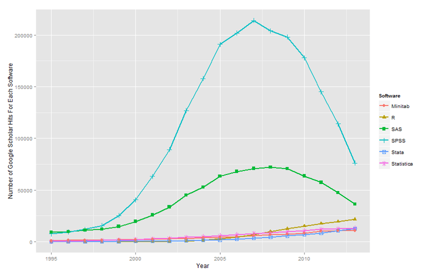

[R Passes SPSS in Scholarly Use, Stata Growing Rapidly (2014)](http://r4stats.com/2014/08/20/r-passes-spss-in-scholarly-use-stata-growing-rapidly/)

R-il on olulisi eeliseid mitmete teiste statistikatarkvarade ees:

- R on eeskätt programmeerimiskeel, mis tähendab, et see võimaldab luua uusi funktsioone vastavalt eesseisvale probleemile;
- R on vabavaraline ning kasvava populaarsusega, mis tähendab, et uute meetodid jõuavad R-i kasutajateni enne teisi;
- R jookseb kõikidel levinud OS-idel ning on tasuta kättesaadav;
- R ühildub mitmete teiste keeltega, mis teeb selle laiemalt kasutatavaks (näiteks käesolev **markdown-i** dokument);
- R pakub visualiseerimisel tõenäoliselt parimat tasakaalu lihtsuse ja esteetilisuse vahel;
- R on tõenäoliselt üks parimaid vahendeid statistika tegemiseks ka aastakümne pärast, mis tähendab, et selle õppimiseks kulutatud aeg pole raisatud.

Sellega seoses on sel ka miinuseid:

- nõuab uue keele õppimist, mis võib olla alguses keeruline;
- aeg ajalt esineb uuemates pakettides vigu, mis tähendab, et tuleb olla tähelepanelik;
- seab kõrgemad nõuded meetodite tundmisele.

## 1.3 Kasulikud lingid

Sissejuhatus:

- [Grammar of Data Manipulation • dplyr](http://dplyr.tidyverse.org)
- [Elegant Data Visualisations Using the Grammar of Graphics • ggplot2](http://ggplot2.tidyverse.org)
- [Date Values](http://www.statmethods.net/input/dates.html)
- [R - Operators](https://www.tutorialspoint.com/r/r_operators.htm)
- [R Markdown](http://rmarkdown.rstudio.com/lesson-1.html)

Jaotus ja keskmised:

- [Tutorial on the R Apply Family](https://www.datacamp.com/community/tutorials/r-tutorial-apply-family#gs.oydmaoU)
- [An Introduction to reshape2](http://seananderson.ca/2013/10/19/reshape.html)

Usaldusvahemikud:

- Bootstrapping

Keskmiste võrdlus:

- case_when

Visualiseerimine:

- [R Color Cheatsheet](https://www.nceas.ucsb.edu/~frazier/RSpatialGuides/colorPaletteCheatsheet.pdf)

Lineaarne regressioon:

- [Stargazer cheatsheet](http://www.jakeruss.com/cheatsheets/stargazer/)

Logistiline regressioon:

- [Eksponentide perekond](https://en.wikipedia.org/wiki/Exponential_family)
- [Binary Outcome GLM Plots](http://thomasleeper.com/Rcourse/Tutorials/binaryglmplots.html)

Huvitavat:

- [John Chambers, S-i looja (intervjuu)](https://www.youtube.com/watch?v=jk9S3RTAl38&ab_channel=StatisticalLearning)
- [John Rauser keynote: Statistics Without the Agonizing Pain](https://www.youtube.com/watch?v=5Dnw46eC-0o&ab_channel=O%27Reilly)

## 1.4 Installeerimiseks

R-i kasutamiseks piisab vaid R-i “mootori” installeerimisest, kuid mugavam on kasutada graafilist kasutajaliidest, näiteks R-Studiot.

- [R](https://www.r-project.org)
- [R studio (GUI)](https://www.rstudio.com/products/rstudio/)

Kuna R on vabavaraline tarkvara, siis on mitmete R-i funktsioonide kasutamiseks vajalik need esmalt alla laadida. See toimub R-i keskkonnas `install.packages(...)` abil (nt `install.packages("tidyverse")`), mispuhul **pakett** on funktsioonide kogum. Vajaminevate pakettide peale hetkel mõtlema ei pea, need tulevad jooksvalt praktikumide käigus.

## 1.5 Kui satud hätta..

R-i pakettidel on enamasti küllatki hästi lahti kirjutatud **help** sektsioon, mis on leitav help tabi alt (enamasti paremal all nurgas). Help tabi otsingusse saab kirjutada otsitud funktsiooni nime, misjärel ta kuvab ta funktsiooni kirjelduse ning argumentide väärtused. Enamasti on lisatud mõned näited funktsiooni kasutamisvõimalustest. Võimalik on veel:

- kirjutada konsooli ?funktsiooni nimi (nt `?read.csv()`) või `help(...)`, kuhu läheb argumendiks funktsiooni nimi;
- selekteerida funktsioon ja vajutada klaviatuuril F1.

Lisaks R-is olemasolevale kirjeldusele on mitmed paketid avaldatud teadusajakirjades, eeskätt ajakirjas [Journal of Statistical Software](https://www.jstatsoft.org/index). Samuti on enamus tüüp-probleemid lahendatud [Stack Overflow](https://stackoverflow.com) lehel. Mõlemal juhul peaks google viima sobiva lahenduseni.

## 1.6 Tööpõhimõtted

### 1.6.1 Objektid

R-i põhiline töövahend on **objekt**, mis võib sisaldada nii funktsioone kui andmeid. Objekte saab ise luua `<-` või `=` märkide abil (`<-` on mõnevõrra kindlam meetod ja mõned soovitavad kasutada seda. Üldjuhul, sh selle aine raames, piisab ka `=` kasutamisest).

```r
x = 5
x
```

```
[1] 5
```

Kui soovime siduda rohkem andmeid ühe objektiga, on võimalik luua **vektor** (jada / ühedimensionaalne maatriks).

```r
x <- c(5, 12.3, 3:10)
x
```

```
 [1]  5.0 12.3  3.0  4.0  5.0  6.0  7.0  8.0  9.0 10.0
```

Objekt võib saada sisendi ka teisest objektidest. Samuti võib teha objektidega tehteid.

```r
y = x - 5
y
```

```
 [1]  0.0  7.3 -2.0 -1.0  0.0  1.0  2.0  3.0  4.0  5.0
```

Objektiks võib olla ka funktsioon.

```r
lahuta.viis = function(x){
  tmp = x - 5
  return(tmp)
}

y = lahuta.viis(x)
y
```

```
 [1]  0.0  7.3 -2.0 -1.0  0.0  1.0  2.0  3.0  4.0  5.0
```

### 1.6.2 Põhilised andmetüübid

Numbrid:

```r
x = 1
str(x)
```

```
 num 1
```

Tähemärgid (numbrid muudetakse tähemärkideks):

```r
x = c("a", "b", 1, 2)
str(x)
```

```
 chr [1:4] "a" "b" "1" "2"
```

Faktorid (identsed elemendid saavad sama koodi):

```r
x = as.factor(c("a", "b", "1", "2", "a", "2"))
str(x)
```

```
 Factor w/ 4 levels "1","2","a","b": 3 4 1 2 3 2
```

Kuupäevad:

```r
x = as.Date("2017-09-01")
str(x)
```

```
 Date[1:1], format: "2017-09-01"
```

Kuupäevade puhul on oluline jälgida formaati. Vaikimisi on selleks **yyyy-mm-dd**, kuid kui sisse loetavad andmed on teises formaadis, tuleks see `as.Date(...)` käskluses täpsustada `format` või `origin` argumentidega. Formaatidest pikemalt: [Date Values](http://www.statmethods.net/input/dates.html).

```r
as.Date("01-09-2017", format="%d-%m-%Y")
```

```
[1] "2017-09-01"
```

```r
as.Date(17410, origin="1970-01-01")
```

```
[1] "2017-09-01"
```

### 1.6.3 Andmetabelid

Seni vaadatud jadad on olnud kõik ühedimensionaalsed, ent andmed võivad olla ka mitmedimensionaalsed. Enimlevinud mitmedimensionaalsed formaadid on **andmetabelid** ja **maatriksid**, millest peamiselt keskendume esimesele. Maatriks on kahedimensionaalne vektor, mis on justkui mitu vektorit kokku liidetuna, kuid kõik vektorid peavad olema sama liiki andmetega.

```r
matrix(1:9, nrow=3, byrow = T)
```

```
     [,1] [,2] [,3]
[1,]    1    2    3
[2,]    4    5    6
[3,]    7    8    9
```

```r
matrix(letters[1:9], nrow=3, byrow = T)
```

```
     [,1] [,2] [,3]
[1,] "a"  "b"  "c"
[2,] "d"  "e"  "f"
[3,] "g"  "h"  "i"
```

Mitu samapikkust vektorit saab liita kokku üheks ka andmetabeliks ehk data frameiks (`data.frame(...)`). Data frame’i erinevus seisneb selles, et veerud võivad sisaldada eritüüpi andmeid (nt üks veerg on numbriline, teine sisaldab faktoreid jne).

```r
x = c(1:4)
y = c("Audi", "DAF", "Ford", "GAZ")
z = x-5

df = data.frame(tunnus.1 = x,
                tunnus.2 = y,
                tunnus.3 = z)
df
```

```
  tunnus.1 tunnus.2 tunnus.3
1        1     Audi       -4
2        2      DAF       -3
3        3     Ford       -2
4        4      GAZ       -1
```

Andmetabelite tunnuseid (ehk veerge) saab kätte ka vektorina kasutades `$` märki:

```r
df$tunnus.2
```

```
[1] Audi DAF  Ford GAZ
Levels: Audi DAF Ford GAZ
```

Võimalik on kasutada ka indeksi (järjekorra) numbrit kandilistes sulgudes. Andmetabelite puhul on esimene number rea number ning koma järel veeru number. Vektori puhul piisab vaid rea numbrist.

```r
df[,2]
```

```
[1] Audi DAF  Ford GAZ
Levels: Audi DAF Ford GAZ
```

```r
df["tunnus.2"]
```

```
  tunnus.2
1     Audi
2      DAF
3     Ford
4      GAZ
```

```r
df[1,]["tunnus.2"]
```

```
  tunnus.2
1     Audi
```

```r
df[1,2]
```

```
[1] Audi
Levels: Audi DAF Ford GAZ
```

```r
df$tunnus.2[2]
```

```
[1] DAF
Levels: Audi DAF Ford GAZ
```

### 1.6.4 Listid

Kõiki erinevaid objekte saab koondada listidesse (`list(...)`). List on hea koondamaks erinevate pikkustega või erineva iseloomuga, kuid samateemalisi andmeid. Tihti võib liste kohata erinevate funktsioonide väljundites.

```r
ls = list(df)
ls[[2]] = c(1:10)
ls[[3]] = y[2:4]

ls
```

```
[[1]]
  tunnus.1 tunnus.2 tunnus.3
1        1     Audi       -4
2        2      DAF       -3
3        3     Ford       -2
4        4      GAZ       -1

[[2]]
 [1]  1  2  3  4  5  6  7  8  9 10

[[3]]
[1] "DAF"  "Ford" "GAZ"
```

### 1.6.5 Funktsioonid objektide kohta

Kõikide objektide puhul:

- `str(...)` - objekti struktuur
- `typeof(...)` - storage mode
- `is.numeric(...)` - kas on…
- `is.character(...)`
- `is.factor(...)`
- `is.function(...)`
- `is.logical(...)`

…

Vektori puhul:

- `length(...)` - vektori pikkus

Data frame’i puhul:

- `dim(...)` - data frame’i dimensioonid (ridu, veerge)
- `nrow(...)` - ridade arv
- `ncol(...)` - veergude arv

Formaadi muutmiseks:

- `as.vector(...)` - vektor
- `as.matrix(...)` - maatriks
- `as.Date(...)` - kuupäev
- `as.data.frame(...)` - data frame
- `as.list(...)` - list

## 1.7 Andmestike laadimine

R suudab lugeda sisse enamikke levinud andmefailide formaate, kuid kõige sagedasemalt kasutatakse .csv (*comma separated values*). Andmestike sisse lugemiseks on erinevaid funktsioone, kuid .csv-de puhul piisab `read.csv(...)`. `read.csv(...)` võimaldab muu hulgas määratleda, kuidas on eraldatud erinevad veerud (`sep`; koma, semikooloni vm abil) ja mida kasutatakse komakohtade eraldamiseks (`dec`; punkt, koma vm). See võib olla oluline, kuna erinevad programmid erinevatel OS-idel võivad kasutada erinevaid standardeid.

### 1.7.1 Internetist

```r
url = "https://martenveskimae.github.io/stat-mod/party_dataset.csv"
df = read.csv(url)
```

Andmestiku vaatamiseks võib küsida tervet andmestikku, aga võib ka küsida esimesi või viimaseid ridu. Selleks saab kasutada nii indeksi kui ka eraldi funktsioone `head(...)` ja `tail(...)`.

```r
df[1:6, 1:4]
```

```
  party support support_emor  last
1   ref    0.36           NA 0.278
2   ref    0.34           NA 0.278
3   ref    0.45           NA 0.278
4   ref    0.43           NA 0.278
5   ref    0.43           NA 0.278
6   ref    0.44           NA 0.278
```

```r
head(df[,1:4])
```

```
  party support support_emor  last
1   ref    0.36           NA 0.278
2   ref    0.34           NA 0.278
3   ref    0.45           NA 0.278
4   ref    0.43           NA 0.278
5   ref    0.43           NA 0.278
6   ref    0.44           NA 0.278
```

```r
tail(df[,1:4])
```

```
    party support support_emor  last
551   sde      NA         0.15 0.152
552   irl      NA         0.06 0.137
553  kesk      NA         0.23 0.248
554   ref      NA         0.26 0.277
555  vaba      NA         0.07 0.087
556  ekre      NA         0.16 0.081
```

Et näha, millised tunnused andmestikus on, võib küsida tunnuste pealkirju `colnames(...)` funktsiooiga.

```r
colnames(df)
```

```
 [1] "party"                 "support"
 [3] "support_emor"          "last"
 [5] "year"                  "month"
 [7] "gov"                   "month_cycle"
 [9] "cycle_constant"        "cycle"
[11] "inflats_m_basevalue"   "inflats_m"
[13] "unemp"                 "gdpgr"
[15] "gdpgr_yearly"          "skp_yearly"
[17] "support_lag1"          "bruto"
[19] "bruto_yearly"          "inflats_prevyear_base"
[21] "alko_suits_base"       "alko_suits_prevyear"
[23] "eluase_base"           "eluase_prevyear"
[25] "irl_meedias"           "kesk_meedias"
[27] "ekre_meedias"          "ref_meedias"
[29] "sde_meedias"           "rohel_meedias"
[31] "date"
```

### 1.7.2 Kohalikult kettalt

Kohalikult kettalt andmestike laadimiseks tuleb märkida ära andmestiku asukoht kettal. Selle lihtsustamiseks on otstarbekas märkida ära töökeskonna asukoht.

Olemasoleva asukoha nägemiseks on funktsioon `getwd()`.

```r
getwd()
```

```
[1] "/Users/martenveskimae/GitHub/stat-mod"
```

Kui tahta seda muuta, saab kasutada `setwd(...)` funktsiooni, kus argumendiks on soovitud uus asukoht.

## 1.8 Andmetega tutvumine

Kokkuvõtvaid andmed nii andmetabelite kui teiste andmeformaatide kohta näeb funktsiooniga `summary(...)`.

```r
summary(df)
```

```
  party        support       support_emor         last
 ekre: 30   Min.   :0.040   Min.   :0.0500   Min.   :0.0810
 irl :124   1st Qu.:0.130   1st Qu.:0.1000   1st Qu.:0.1520
 kesk:124   Median :0.210   Median :0.1600   Median :0.2100
 ref :124   Mean   :0.204   Mean   :0.1601   Mean   :0.2014
 sde :124   3rd Qu.:0.260   3rd Qu.:0.2200   3rd Qu.:0.2610
 vaba: 30   Max.   :0.450   Max.   :0.2800   Max.   :0.2900
            NA's   :34      NA's   :418      NA's   :12
      year          month             gov          month_cycle
 Min.   :2007   Min.   : 1.000   Min.   :0.0000   Min.   : 1
 1st Qu.:2010   1st Qu.: 3.000   1st Qu.:0.0000   1st Qu.:11
 Median :2012   Median : 6.000   Median :1.0000   Median :20
 Mean   :2012   Mean   : 6.378   Mean   :0.5665   Mean   :22
 3rd Qu.:2015   3rd Qu.: 9.000   3rd Qu.:1.0000   3rd Qu.:33
 Max.   :2017   Max.   :12.000   Max.   :1.0000   Max.   :49
                                                  NA's   :12
 cycle_constant     cycle         inflats_m_basevalue   inflats_m
 Min.   :49     Min.   :0.02041   Min.   :108.5       Min.   :-0.90701
 1st Qu.:49     1st Qu.:0.22449   1st Qu.:124.7       1st Qu.:-0.03494
 Median :49     Median :0.40816   Median :138.0       Median : 0.28775
 Mean   :49     Mean   :0.44898   Mean   :134.2       Mean   : 0.30774
 3rd Qu.:49     3rd Qu.:0.67347   3rd Qu.:143.9       3rd Qu.: 0.64917
 Max.   :49     Max.   :1.00000   Max.   :146.3       Max.   : 2.08868
 NA's   :12     NA's   :12        NA's   :72          NA's   :180
     unemp            gdpgr            gdpgr_yearly
 Min.   : 4.000   Min.   :-10.80000   Min.   :-18.4000
 1st Qu.: 6.500   1st Qu.: -0.30000   1st Qu.: -1.7000
 Median : 8.000   Median :  0.70000   Median :  2.3000
 Mean   : 9.141   Mean   : -0.01209   Mean   :  0.7391
 3rd Qu.:11.300   3rd Qu.:  1.30000   3rd Qu.:  5.6000
 Max.   :19.500   Max.   :  3.70000   Max.   : 11.6000
 NA's   :78       NA's   :192         NA's   :162
   skp_yearly        support_lag1        bruto         bruto_yearly
 Min.   :-19.3000   Min.   :0.0700   Min.   : 659.7   Min.   :-6.500
 1st Qu.:  0.3000   1st Qu.:0.1500   1st Qu.: 792.3   1st Qu.: 3.900
 Median :  1.9000   Median :0.2300   Median : 857.1   Median : 6.300
 Mean   :  0.8247   Mean   :0.2231   Mean   : 898.4   Mean   : 6.707
 3rd Qu.:  5.2000   3rd Qu.:0.2800   3rd Qu.:1010.0   3rd Qu.: 8.500
 Max.   : 10.5000   Max.   :0.4500   Max.   :1163.0   Max.   :21.166
 NA's   :78         NA's   :184      NA's   :84       NA's   :192
```

[output cut: 9 more lines]

```
 Min.   :106.1   Min.   : 227.0   Min.   : 312.0   Min.   :  8.0
 1st Qu.:144.7   1st Qu.: 438.5   1st Qu.: 559.8   1st Qu.: 29.0
 Median :158.0   Median : 559.0   Median : 626.5   Median : 51.5
 Mean   :159.5   Mean   : 610.4   Mean   : 717.0   Mean   :115.7
 3rd Qu.:183.2   3rd Qu.: 730.2   3rd Qu.: 811.5   3rd Qu.:111.0
 Max.   :199.0   Max.   :1597.0   Max.   :2414.0   Max.   :673.0
 NA's   :126     NA's   :316      NA's   :316      NA's   :316
  ref_meedias      sde_meedias     rohel_meedias            date
 Min.   : 343.0   Min.   : 245.0   Min.   :  8.00   2015-01-01:  6
 1st Qu.: 537.8   1st Qu.: 367.0   1st Qu.: 26.75   2015-02-01:  6
 Median : 658.5   Median : 444.5   Median : 49.00   2015-03-01:  6
 Mean   : 747.7   Mean   : 510.6   Mean   : 85.40   2015-04-01:  6
 3rd Qu.: 929.0   3rd Qu.: 585.8   3rd Qu.:103.00   2015-05-01:  6
 Max.   :1836.0   Max.   :1480.0   Max.   :462.00   2015-06-01:  6
 NA's   :316      NA's   :316      NA's   :316      (Other)   :520
```

Faktortunnuste puhul võib pakkuda huvi, millised erinevad kategooriad on andmestikus esindatud. Näiteks võime vaadata, millised erakonnad andmestikus leiduvad.

```r
levels(df$party)
```

```
[1] "ekre" "irl"  "kesk" "ref"  "sde"  "vaba"
```

Kui soovida täpsemat ülevaadet, näiteks, mitu andmepunkti on iga erakonnaga seotud, siis selleks on hea kasutada paketti **tidyverse**. Tidyverse hõlmab endas mitmeid erinevaid, kuid omavahel ühilduvaid pakette. Üks neist, **dplyr**, pakub mitmeid funktsioone andmete mugavaks töötlemiseks (eeskätt filtreerimine, grupeerimine, tunnuste muutmine jne). Teine oluline eelis tuleneb paketist **magrittr**, mis võimaldab käsklusi sisestada jadana (ing.k *pipe*). See kiirendab tööprotsessi ja muudab R-i koodi kergemini jälgitavaks. Pipe’ide kasutamiseks tuleb kahe funktsiooni vahel lisada `%>%` sümbolid. Enne näite juurde liikumist on vajalik tidyverse aktiveerida, milleks on funktsioon `library(...)`.

```r
library(tidyverse)
```

Pipe’i näide võib olla järgnev:

```r
c(1:10) %>% lahuta.viis()
```

```
 [1] -4 -3 -2 -1  0  1  2  3  4  5
```

Järgnevalt tutvume, mitu rida on seotud üksikute erakondadega (sagedustabel).

```r
df %>%
  group_by(party) %>%
  summarize(n = n())
```

```
# A tibble: 6 x 2
   party     n
  <fctr> <int>
1   ekre    30
2    irl   124
3   kesk   124
4    ref   124
5    sde   124
6   vaba    30
```

**dplyr** kohta leiab rohkem informatsiooni siit: [Grammar of Data Manipulation • dplyr](http://dplyr.tidyverse.org)

## 1.9 Filtreerimine & joonised

Kõige kiirem viis andmete visualiseerimiseks on kasutada funktsioone `plot(...)` või `hist(...)`, kus tuleb määratleda telje/telgede väärtused.

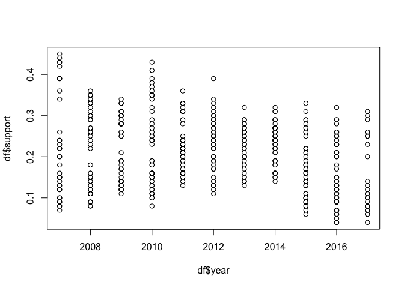

```r
plot(df$year, df$support)
```

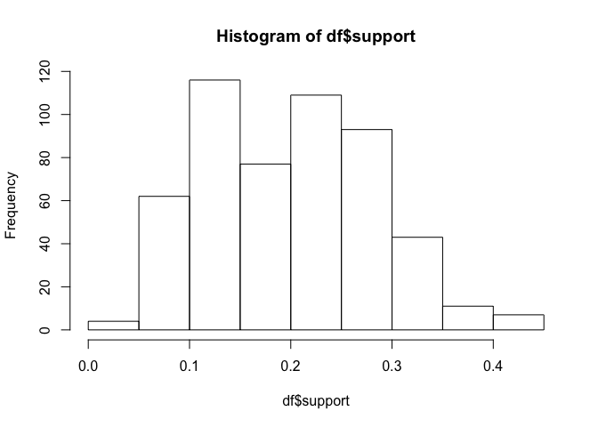

```r
hist(df$support)
```

Paraku ei ole antud funktsioonid väga mugavad tidyverse’is kasutamiseks ning kujunduse muutmine on piiratud võimalustega. Kõige enim levinud viis andmete visualiseerimiseks R-i keskkonnas on paketiga **ggplot2**, mis on samuti tidyverse’i osa.

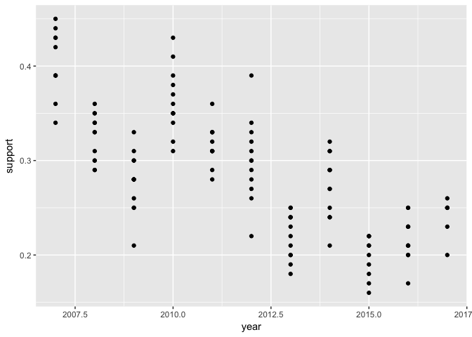

```r
df %>%
  filter(party=="ref") %>%
  ggplot() +
  geom_point(aes(year, support))
```

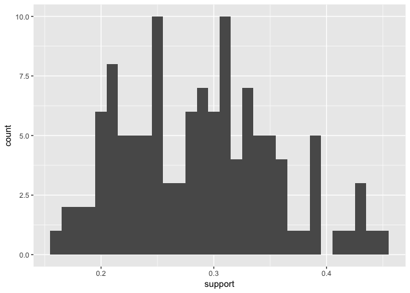

```r
df %>%
  filter(party=="ref") %>%
  ggplot() +
  geom_histogram(aes(support))
```

**Võrdlusoperaatorid**

Filtreerimisel või muude võrdluste tegemisel kasutatakse teatud tingmärke, mida nimetatakse võrldusoperaatoriteks. R-is on need järnevad:

| Operaator | Tulemus |
| --- | --- |
| `==` | Võrdne |
| `!=` | Mittevõrdne |
| `>` | Suurem |
| `<` | Väiksem |
| `>=` | Suurem-võrdne |
| `<=` | Väiksem-võrdne |
| `%in%` | Sisaldab |

**Loogilised operaatorid**

Olukordades, kus soovime mitut võrdlust/tingimust kombineerida, tuleb erinevad komponendid siduda omavahel loogiliste operaatoritega:

| Operaator | Tulemus |
| --- | --- |
| `&` | Loogiline JA üksikute vektori komponentide kohta (väljund on TRUE/FALSE kõigi vektori komponentide kohta) |
| `&&` | Loogiline JA kõigi vektori komponentide kohta (väljund on ainult üks TRUE/FALSE kogu vektori kohta) |
| `\|` | Loogiline VÕI üksikute vektori komponentide kohta (väljund on TRUE/FALSE kõigi vektori komponentide kohta) |
| `\|\|` | Loogiline VÕI kõigi vektori komponentide kohta (väljund on ainult üks TRUE/FALSE kogu vektori kohta) |
| `!` | Loogiline mittesamaväärsus |

Näiteid: [R - Operators](https://www.tutorialspoint.com/r/r_operators.htm)

Kujunduse kiireks muutmiseks on erinevad valmislahendused, algusega `theme_`.

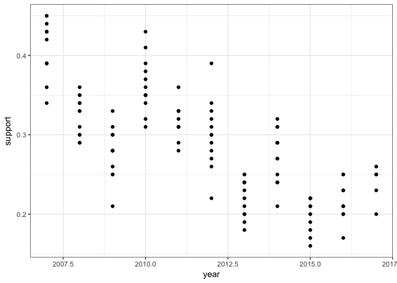

```r
df %>%
  filter(party=="ref") %>%
  ggplot() +
  geom_point(aes(year, support)) +
  theme_bw()
```

**ggplot2** kohta leiab rohkem informatsiooni siit: [Elegant Data Visualisations Using the Grammar of Graphics](http://ggplot2.tidyverse.org)

# 2 Jaotus ja keskmised

### 2.0.1 Paketid

```r
library(tidyverse)
library(e1071)
library(reshape2)
```

### 2.0.2 Andmestik

```r
df = read.csv("https://martenveskimae.github.io/stat-mod/party_dataset.csv")
```

## 2.1 Histogramm

Vaatame jaotuste järsakust ja sümmeetrilisust visuaalselt histogrammi abil. `geom_histogram(...)` annab vaikimisi sagedusjaotuse, kuid on võimalik valida ka protsente või tõenäosustihedust.

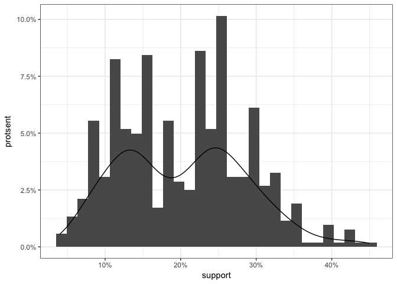

```r
df %>%
  ggplot() +
  geom_histogram(aes(support, ..count../sum(..count..))) +
  geom_line(aes(support, ..density../100), stat = "density") +
  scale_y_continuous(labels=scales::percent) +
  scale_x_continuous(labels=scales::percent) +
  labs(y="protsent") +
  theme_bw()
```

**ggplot** võimaldab luua eraldi joonised erinevate gruppide jaoks kasutades `facet_wrap(...)` käsklust.

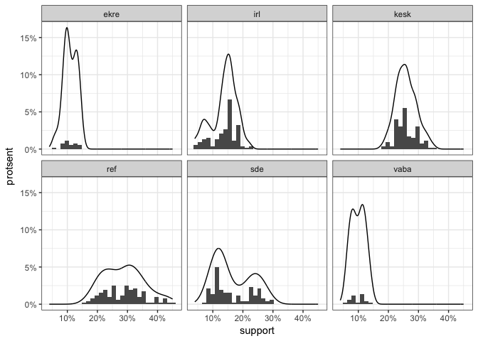

```r
df %>%
  ggplot() +
  geom_histogram(aes(support, ..count../sum(..count..))) +
  geom_line(aes(support, ..density../100), stat = "density") +
  facet_wrap(~party) +
  scale_y_continuous(labels=scales::percent) +
  scale_x_continuous(labels=scales::percent) +
  labs(y="protsent") +
  theme_bw()
```

Silmas tuleb pidada, et sel puhul kalkuleerib **ggplot** tulpade laiused ja hulga üle kõikide kuvatud jooniste, mistõttu erinevad need üksikult kuvatud joonistest. Tulpade hulga ja laiuste kontrollimiseks on argumendid `bins` ja `binwidth`, millest esimene määrab tulpade hulga ja teine laiused. Neid käsklusi ei saa korraga kasutada (binwidth kirjutab binsi üle).

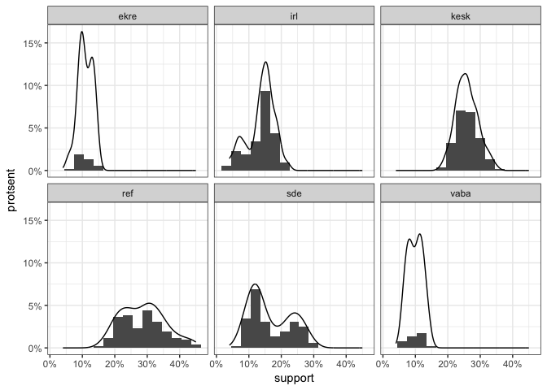

```r
df %>%
  ggplot() +
  geom_histogram(aes(support, ..count../sum(..count..)), bins=10, binwidth=0.03) +
  geom_line(aes(support, ..density../100), stat = "density") +
  facet_wrap(~party) +
  scale_y_continuous(labels=scales::percent) +
  scale_x_continuous(labels=scales::percent) +
  labs(y="protsent") +
  theme_bw()
```

## 2.2 Järsakuse- ja assümmeetriakordaja

Vaatame järsakust ja sümmeetrilisust ka numbriliselt nn järsakuse- ja assümmeetriakordaja abil. Seda võimaldab pakett **e1071**, kust leiame käsklused `skewness(...)` ja `kurtosis(...)` (rakendatavad valemid on leitavad helpist). Kuna soovime rakendada antud käsklusi kõigi gruppide (erakondade) jaoks eraldi, siis tuleks andmestik esmalt filtreerida grupeerimistunnuse alusel (party) ning alles seejärel rakendada antud käsklusi.

```r
df %>%
  group_by(party) %>%
  summarise(skewness = skewness(support, na.rm=T),
            kurtosis = kurtosis(support, na.rm=T))
```

```
# A tibble: 6 x 3
   party    skewness   kurtosis
  <fctr>       <dbl>      <dbl>
1   ekre -0.23712096 -0.8569726
2    irl -0.61654227 -0.2531924
3   kesk  0.29345645 -0.2409381
4    ref  0.30822221 -0.5851121
5    sde  0.44024113 -1.2410302
6   vaba  0.01834276 -1.3350304
```

Alternatiiv **dplyr** meetodile oleks **for loop**. Loopimine on küll võrdlemisi lihtne, kuid vahel mitte kõige efektiivsem viis:

```r
parties = as.character(unique(df$party))
s = c()
k = c()
for(i in 1:length(parties)){
  s[length(s)+1] = skewness(df$support[df$party==parties[i]], na.rm=T)
  k[length(k)+1] = kurtosis(df$support[df$party==parties[i]], na.rm=T)
}
names(s) = parties
names(k) = parties
s;k
```

```
        ref        kesk         irl         sde        vaba        ekre
 0.30822221  0.29345645 -0.61654227  0.44024113  0.01834276 -0.23712096
```

```
       ref       kesk        irl        sde       vaba       ekre
-0.5851121 -0.2409381 -0.2531924 -1.2410302 -1.3350304 -0.8569726
```

Sama tulemuse saab efektiivsemalt kasutades `apply(...)` käsklust (antud juhul `sapply(...)`. Rohkem applyst: [Tutorial on the R Apply Family](https://www.datacamp.com/community/tutorials/r-tutorial-apply-family#gs.oydmaoU)), mis jäljendab eelneva meetodi loogikat.

```r
s = sapply(as.character(unique(df$party)), function(x) skewness(df$support[df$party==x], na.rm=T))
k = sapply(as.character(unique(df$party)), function(x) kurtosis(df$support[df$party==x], na.rm=T))
s;k
```

```
        ref        kesk         irl         sde        vaba        ekre
 0.30822221  0.29345645 -0.61654227  0.44024113  0.01834276 -0.23712096
```

```
       ref       kesk        irl        sde       vaba       ekre
-0.5851121 -0.2409381 -0.2531924 -1.2410302 -1.3350304 -0.8569726
```

## 2.3 Keskmine, mediaan ja mood

Moodi, ehk kõige sagedamini esineva väärtuse leidmiseks eraldi käsklus puudub, ent seda on lihtne leida sagedustabelist.

```r
df %>%
  group_by(party, support) %>%
  summarise(n = n()) %>%
  na.omit() %>%
  group_by(party) %>%
  summarise(mode = support[n==max(n)][1])
```

```
# A tibble: 6 x 2
   party  mode
  <fctr> <dbl>
1   ekre  0.10
2    irl  0.16
3   kesk  0.26
4    ref  0.25
5    sde  0.12
6   vaba  0.11
```

**dplyri** saab kasutada ka keskmise ja mediaani leidmiseks.

```r
df %>%
  group_by(party) %>%
  summarise(mean = mean(support,na.rm=T),
            median = median(support,na.rm=T))
```

```
# A tibble: 6 x 3
   party       mean median
  <fctr>      <dbl>  <dbl>
1   ekre 0.10952381   0.10
2    irl 0.13875000   0.15
3   kesk 0.25858333   0.26
4    ref 0.28716667   0.29
5    sde 0.16633333   0.14
6   vaba 0.09904762   0.10
```

Viimaks võib kanda leitud väärtused histogrammile, et neid visuaalselt kõrvutada. Kuigi **ggplot** oskab lisada joonistele funktsioone, ei suuda ta praeguses versioonis kuvada eraldi funktsioone eraldi gruppidele (nt kasutades `facet_wrap(~party)`). Otstarbekas on sellisel juhul teha uus andmetabel keskmiste väärtustega. Andmetabeli mugavamaks kasutamiseks pöörame tabeli *laiast* formaadist *pikka* formaati, kasutades selleks **reshape2** paketti ja `melt(...)` funktsiooni. Rohkem **reshape2** ja laia/pika formaadi kohta: [An Introduction to reshape2](http://seananderson.ca/2013/10/19/reshape.html).

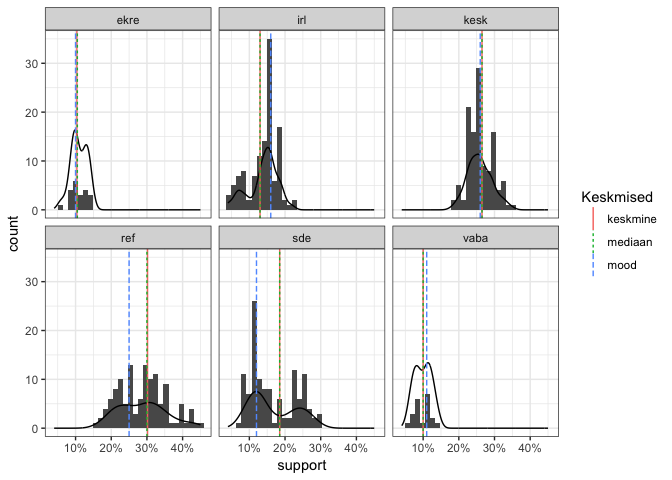

```r
keskmised = df %>%
  group_by(party, support) %>%
  summarise(n = n()) %>%
  na.omit() %>%
  group_by(party) %>%
  summarise(keskmine = mean(support),
            mediaan = median(support),
            mood = support[n==max(n)][1]) %>%
  melt("party",c("keskmine", "mediaan", "mood"),"Keskmised")

df %>%
  ggplot() +
  geom_histogram(aes(support)) +
  geom_line(aes(support, ..density..), stat = "density") +
  geom_vline(data=keskmised,aes(xintercept=value, linetype=Keskmised, color=Keskmised)) +
  facet_wrap(~party) +
  scale_x_continuous(labels=scales::percent) +
  theme_bw()
```

Lisaks mediaanile võivad huvipakkuvad olla ka teised **protsentiilid** (mediaan on 50 protsentiil), eeskätt 25 ja 75 (teisisõnu I ja III kvartiil). Veel võib aeg-ajalt kohta mõistet **kvartiilhaare** (*interquartile range - IQR*), mis tähistab vahemikku I ja III kvartiili vahel. R-is on protsentiilide leidmiseks käsklus `quantile(...)`.

```r
sapply(as.character(unique(df$party)), function(x) quantile(df$support[df$party==x],c(.025,.25,.5,.75,.975),na.rm=T))
```

```
          ref   kesk     irl     sde  vaba ekre
2.5%  0.17975 0.2000 0.04975 0.08000 0.065 0.07
25%   0.23000 0.2375 0.12000 0.11750 0.080 0.10
50%   0.29000 0.2600 0.15000 0.14000 0.100 0.10
75%   0.33000 0.2800 0.16000 0.23000 0.120 0.13
97.5% 0.43000 0.3300 0.20025 0.28025 0.135 0.14
```

Eelnevalt toodud protsentiilid saab graafida **boxploti** abil, mis kuvab veel lisaks erindid (*outliers*).

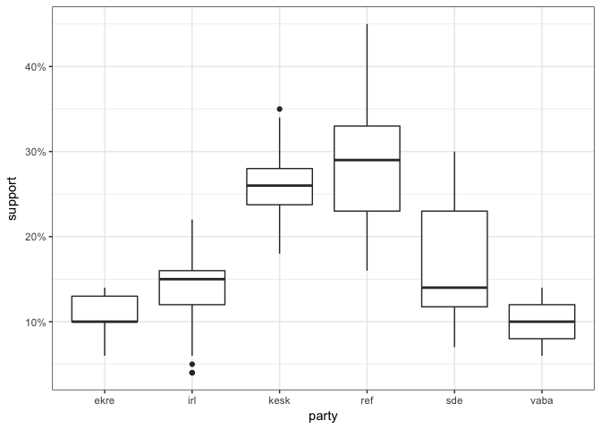

```r
df %>%
  ggplot() +
  geom_boxplot(aes(party,support)) +
  scale_y_continuous(labels=scales::percent) +
  theme_bw()
```

# 3 Usaldusvahemikud

### 3.0.1 Paketid

```r
library(tidyverse)
library(reshape2)
```

### 3.0.2 Andmestik

```r
df = read.csv("https://martenveskimae.github.io/stat-mod/party_dataset.csv")
```

## 3.1 Standardhälve

Eelmisest korrast teame, et keskmine toetusprotsent erakonniti erineb, aga erineb ka kõikumine keskmise ümber. Osade erakondade puhul on keskmine toetus stabiilselt ühe tüüpväärtuse ümber, aga teistel mitte. Selle hindamiseks kasutatakse tüüpiliselt *variatsiooni* ja *standardhälvet*, mis on R-is leitav käsklustega `var(...)` ja `sd(...)`.

Variatsioon on *eeldatav* erinevus tõelise väärtuse ja keskmise vahel ruudus:

$Var(X) = E[(X-\mu)^2]$

ehk teisisõnu erinevuste keskmine:

$Var(X) = \frac{ \sum(X-\mu)^2}{N-1}$

```r
X = 1:10

var(X)
```

```
[1] 9.166667
```

```r
sum((X - mean(X))^2) / (length(X)-1)
```

```
[1] 9.166667
```

(Miks on jagaja $N-1$ ja mitte $N$? Vahe tuleneb sellest, kas meil on andmed kogu populatsiooni kohta või valim populatsioonist, mis on alati väiksem kui N!)

Variatsiooni leidmiseks on erinevused võetud ruutu. Et jõuda tagasi algskaala juurde, tuleks variatsioonist võtta ruutjuur, mis ongi standardhälve:

$\sigma=\sqrt{E[(X-\mu)^2]}$

```r
X = 1:10

sqrt(var(X))
```

```
[1] 3.02765
```

```r
sd(X)
```

```
[1] 3.02765
```

Standardhälvet võib seega mõista kui keskmist erinevust keskmisest.

Vaatame erakondade keskmisi ja standardhälvet lähemalt:

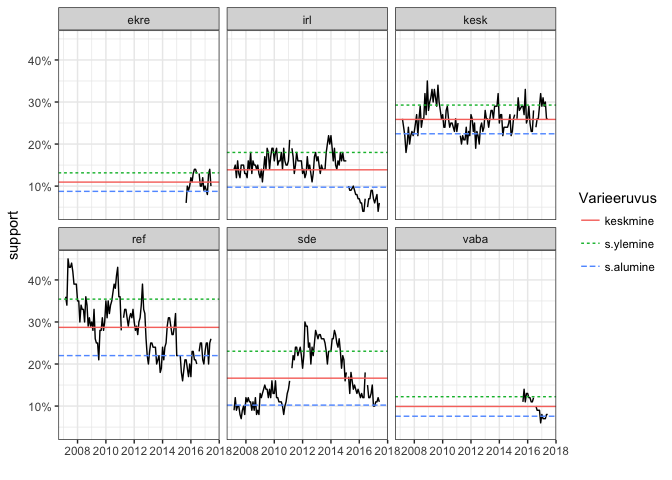

```r
keskmised = df %>%
  group_by(party) %>%
  summarise(keskmine = mean(support, na.rm=T),
            s.ylemine = keskmine + sd(support, na.rm=T),
            s.alumine = keskmine - sd(support, na.rm=T)) %>%
  melt("party",c("keskmine", "s.ylemine", "s.alumine"), "Varieeruvus")

df %>%
  ggplot() +
  geom_line(aes(as.Date(date), support)) +
  geom_hline(data=keskmised,aes(yintercept=value, linetype=Varieeruvus, color=Varieeruvus)) +
  facet_wrap(~party) +
  scale_y_continuous(labels=scales::percent) +
  labs(x="") +
  theme_bw()
```

## 3.2 Standardviga ja usaldusvahemikud

Millest see kõikumine keskmine ümber tuleneb on meile teada. Erakondade toetus varieerub ajas erinevalt ja meie arvutatud keskmine näitab tüüpväärtust üle aja. Siin on aga veel üks aga! Erakonna igakuised toetusnumbrid on ise sammuti üks statistiline hinnang (enamasti saadud umbes 1000se valimiga küsitlusest)! Milline on erakondade tõeline toetus populatsioonis on kindlaks tehtav vaid kogupopulatsiooni küsitledes ja seda me teha ei saa. Sellest tulenevalt on meie küsitlustulemustes alati mingi viga sees. Mida saame teha, on hinnata toetusprotsendi vahemikku, kus tõeline toetusprotsent tõenäoliselt asetseks.

Teoreetiliselt tähendaks see olukorda, kus võtaksime populatsioonist, kus on tegelikud teotused erakondadele, lõpmatu arv juhuvalimeid ja leiaks nende valimite toetusprotsendid. Enamasti oleks tulemus sarnane tegeliku toetusega (mida me ei tea), samas teatud olukordades oleks tulemus ühele või teisele poole väga mööda. Kui me teeks nendelt juhuvalimitelt toetusprotsentide graafi, tuleks see normaaljaotusega graaf: 95% juhtumitest langeks +/-1.96 z-skoori vahele. Sellest tulenevalt saaksime hinnata, millisesse vahemikku jääb tõeline tulemus (95% tõenäosusega).

Praktikas seda teha ei saa, sest küsitlused on kallid. Küll aga on võimalik tuletada usaldusvahemik kasutades selleks **standardviga**. Standardviga kirjeldab, kui lähedal on valimi keskmine populatsiooni keskmisele, kasutades selleks üldjuhul variatsiooni ja valimi suurust. Standardvea leidmiseks on erinevaid meetodeid, sõltuvalt andmete iseloomust. Antud juhul on tegu proportsioonidega (erakonna toetust väljendatakse protsendina populatsioonist), mispuhul kasutame proportsiooni standardviga:

$SE_p = \sqrt{\frac{p(1-p)}{N}}$

kus:

- p on protsent (antud juhul erakonna toetusprotsent)
- N valimi suurus (antud juhul 1000)

Usaldusvahemiku leidmiseks tuleb korrutada standardviga soovitud z-skoori väärtusega (nt 95% usaldusvahemiku leidmiseks on see 1.96) ning liita või lahutada erakonna toetusprotsendist:

$p \pm ci_{95} = p \pm 1.96 \cdot SE$

Kuivõrd tegu on küllalt spetsiifilise küsimusega, siis on otstarbekas teha oma funktsioon.

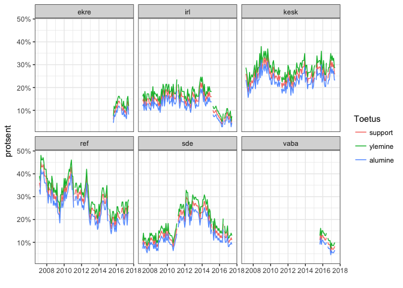

```r
ci = function(p,n=1000,z=1.96){
  list(u = p + (z*(sqrt(p*(1-p)/n))),
       l = p - (z*(sqrt(p*(1-p)/n))))
}

df %>%
  mutate(ylemine =  ci(support)[["u"]],
         alumine =  ci(support)[["l"]]) %>%
  melt(c("party", "date"), c("support", "ylemine", "alumine"),"Toetus") %>%
  ggplot() +
  geom_line(aes(as.Date(date), value, color=Toetus)) +
  facet_wrap(~party) +
  scale_y_continuous(labels=scales::percent) +
  labs(x="",y="protsent") +
  theme_bw()
```

Lihtsamaks lugemiseks võime jooned üle siluda.

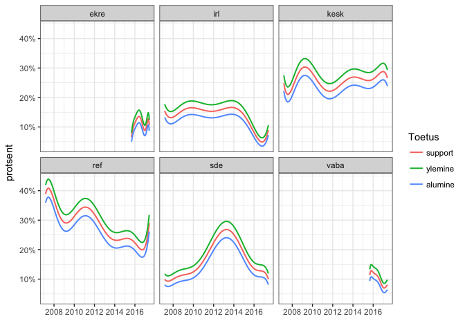

```r
df %>%
  mutate(ylemine =  ci(support)[["u"]],
         alumine =  ci(support)[["l"]]) %>%
  melt(c("party", "date"), c("support", "ylemine", "alumine"),"Toetus") %>%
  ggplot() +
  geom_smooth(aes(as.Date(date), value, color=Toetus), se=F, method="lm", formula= y~poly(x, 7), size=.7) +
  facet_wrap(~party) +
  scale_y_continuous(labels=scales::percent) +
  labs(x="",y="protsent") +
  theme_bw()
```

Alternatiivne lähenemine eelnevalt kirjeldatud meetodile oleks simuleerida erakondade toetusprotsente bootstrap meetodil. Bootstrapi idee seisneb olemasolevast valimist juhuslike valimite võtmises ning nende põhjal huvipakkuvate statistikute arvutamises (eeskätt variatsioon ja standardviga).

Mündiviske simulatsiooniks kasutame paketti **mosaic** ning funktsioone `do(...)`, `rFlip(...)` ja `confint(...)`. Käesolevas katses: `do(1000)` kordab katset 1000 korda ning `rFlip(party.n,x)` viskab ühes katses münti nii mitu korda, kui palju on erakonnaga seotud vaatlusi, tõenäosusega x. `confint(...)` arvutab simulatsiooni usaldusvahemikud.

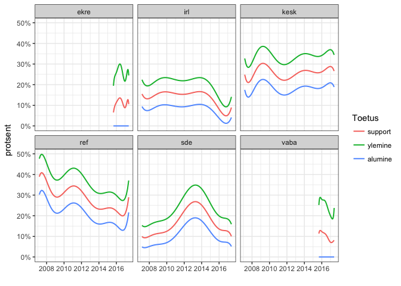

```r
toetus.sim = function(x,party){
  require(mosaic)
  if(is.na(x)) return(NA)
  party.n = nrow(df[df$party==party & !is.na(df$support),])
  tmp = do(1000) * rflip(party.n,x)
  ci = confint(tmp$prop)
  list(u = ci[["97.5%"]],
       l = ci[["2.5%"]])
}

df %>%
  rowwise() %>%
  mutate(ylemine = toetus.sim(support,party)[["u"]],
         alumine = toetus.sim(support,party)[["l"]]) %>%
  melt(c("party", "date"), c("support", "ylemine", "alumine"),"Toetus") %>%
  ggplot() +
  geom_smooth(aes(as.Date(date), value, color=Toetus), se=F, method="lm", formula= y~poly(x, 7), size=.7) +
  facet_wrap(~party) +
  scale_y_continuous(labels=scales::percent) +
  labs(x="",y="protsent") +
  theme_bw()
```

# 4 Keskmiste võrdlus

### 4.0.1 Paketid

```r
library(tidyverse)
library(effsize)
```

### 4.0.2 Andmestik

```r
df = read.csv("https://martenveskimae.github.io/stat-mod/party_dataset.csv")
paneel = read.csv("https://martenveskimae.github.io/stat-mod/ep2014_paneel.csv")
```

## 4.1 T-test

Vaatame Eesti poliitika sukka ja saabast ehk Reformierakonda ja Keskerakonda eelmise valimistsükli ajal.

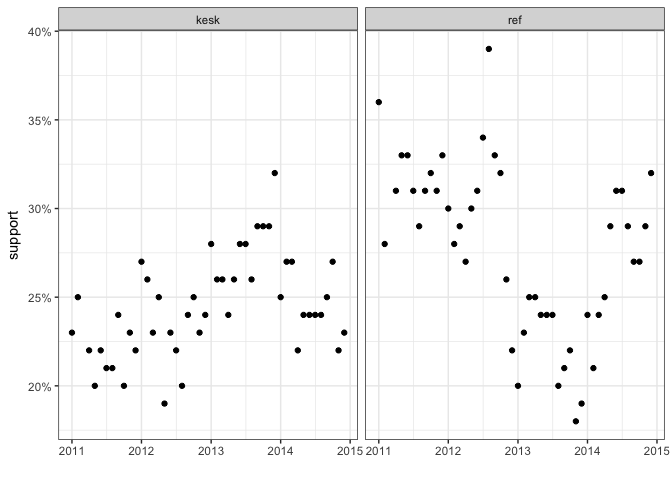

```r
df %>%
  filter(party %in% c("ref", "kesk"),
         year>=2011 & year<2015) %>%
  ggplot() +
  geom_point(aes(as.Date(date),support)) +
  facet_wrap(~party) +
  scale_y_continuous(labels=scales::percent) +
  labs(x="") +
  theme_bw()
```

Nende keskmine toetus on antud perioodil:

```r
df %>%
  filter(party %in% c("ref", "kesk"),
         year>=2011 & year<2015) %>%
  group_by(party) %>%
  summarise(keskmine = mean(support,na.rm=T))
```

```
# A tibble: 2 x 2
   party  keskmine
  <fctr>     <dbl>
1   kesk 0.2444681
2    ref 0.2772340
```

Tekib küsimus, kas Keskerakonna keskmine toetus üldse erineb oluliselt Reformi keskmisest toetusest? Kahe keskmise võrdlemiseks saab kasutada t-testi meetodit (R-is `t.test(...)`), mis hindab, kas kaks keskmist pärinevad samast populatsioonist või on tegu erinevate gruppidega. Lihtsustatult öeldes, võrreldakse t-testis keskmiste erinevust kogu variatsiooniga, ning hinnatakse saadud tulemuse tõenäosust (kas tegu oli tõenäolise või ebatõenäolise tulemusega, ehk statistiliselt oluline või mitte). T-testi eelduseks on, et mõlemad valimid on normaaljaotuslikud ning sarnase variatiivsusega (viimast eeldust on võimalik rikkuda kasutades “robustset” t-testi, kus vabadusastmeid arvutatakse teisel meetodil!; R kasutab vaikimisi robustset versiooni - argument `var.equal = FALSE`).

T-statistiku arvutamiseks ühe valimi puhul on valemiks:

$t=\frac{\bar{x}-\mu_o}{\frac{s}{\sqrt{N}}}$

kus

- $\mu_0$ on võrreldav keskmine
- s on valimi standardhälve

..kahe sõltumatu valimi puhul:

$t=\frac{\bar{x_1}-\bar{x_2}}{\sqrt{\frac{s_1^2}{n_1}+\frac{s_2^2}{n_2}}}$

..ja kahe sõltuva valimi puhul:

$t=\frac{\frac{\sum{d}}{N}}{\sqrt{\frac{\sum{d^2}-\frac{(\sum{d^2})}{N}}{N(N-1)}}}$

kus

- d on paaris olevate väärtuste erinevus
- N on paaride arv

Teeme meetodi illustreerimiseks simulatsiooni. Ütleme, et meil on kaks sõltumatut normaaljaotusega vektorit, mõlemad 50 vaatlusega. Arvutame vektorite t-testi tulemused ja kordame katset 1000 korda (iga kord uute andmetega).

```r
t.statistikud = replicate(1000, t.test(rnorm(50), rnorm(50))$statistic)
```

Vaatame saadud t-statistikute jaotust visuaalselt

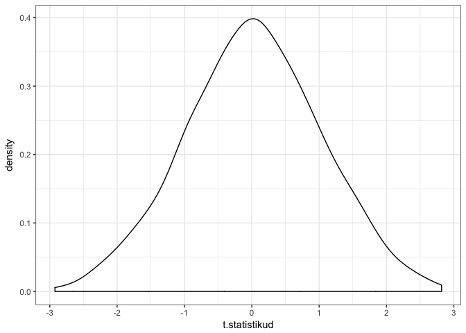

```r
ggplot() +
  geom_density(aes(t.statistikud)) +
  theme_bw()
```

Kui meie eeldused peavad paika, siis peaks tulemus lähenema t-jaotusele vabadusastmel 98 (50+50-2). Genereerime t-jaotuse antud vabadusastmetega ja arvutame 95% usaldusvahemikud. T-jaotuse leidmiseks peaksime leidma t-statistikute umbkaudsed otspunktid, näiteks käsklusega `range(...)`, seejärel looma sümmeetrilise (sest t-jaotus on sümmeetriline!) vektori käsklusega `seq(...)` ning arvutama saadud vektori t-jaotusliku tiheduse etteantud vabadusastmete puhul (praegu 98), kasutades käsklust `dt(...)`. Nendest saavad teoreetilise jaotuse x ja y atribuudid. Usaldusvahemike leidmiseks kasutame käsklust `qt(..)`, mis arvutab teoreetilise jaotuse kvantiilid (praegu 0.025 ja 0.975).

Lisame tulemused eelnenud graafile.

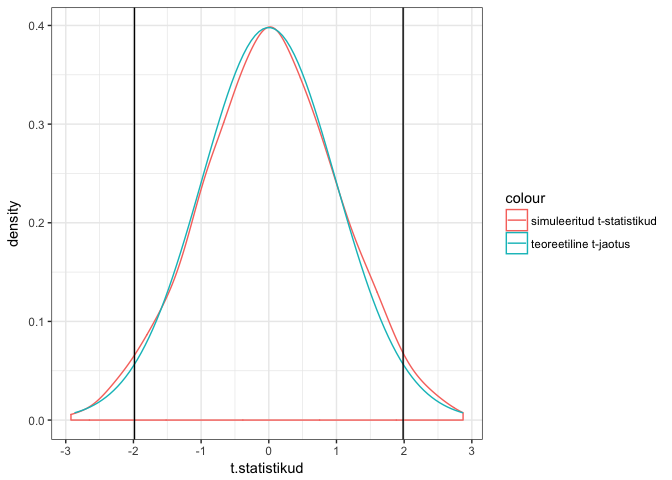

```r
r = mean(abs(range(t.statistikud)))
x = seq(-r,r,length=100)
y = dt(x,df=98)

a95 = qt(c(.025, .975), df=98)

ggplot() +
  geom_density(aes(t.statistikud,color="simuleeritud t-statistikud")) +
  geom_line(aes(x,y,color="teoreetiline t-jaotus")) +
  geom_vline(xintercept = a95[1]) +
  geom_vline(xintercept = a95[2]) +
  theme_bw()
```

Joonte vahele jäänud tulemused olid statistiliselt ebaolulised ning servadesse sattunud tulemused statistiliselt olulised 95% usaldusnivoo puhul. Võime arvutada, mitu protsenti osutus olulisteks.

```r
length(t.statistikud[t.statistikud<=a95[1] | t.statistikud>=a95[2]]) / length(t.statistikud)
```

```
[1] 0.053
```

### 4.1.1 Ühe valimi t-test

Hindame seda esmalt ühe valimi t testiga. Leiame Reformierakonna keskmise toetuse perioodil 2011-2014 ja võrdleme seda keskerakonna toetusega.

```r
ref.keskmine = df %>%
  filter(party == "ref",
         year>=2011 & year<2015) %>%
  pull(support) %>%
  na.omit() %>%
  mean()

kesk = df %>%
  filter(party == "kesk",
         year>=2011 & year<2015) %>%
  pull(support) %>%
  na.omit()

t.test(kesk, mu=ref.keskmine)
```

```
    One Sample t-test

data:  kesk
t = -8.034, df = 46, p-value = 2.635e-10
alternative hypothesis: true mean is not equal to 0.277234
95 percent confidence interval:
 0.2362586 0.2526775
sample estimates:
mean of x
0.2444681
```

### 4.1.2 Kahe sõltumatu valimi t-test

Kas valitsuse ja opositsiooni toetus erineb üldse oluliselt erinevatel ajahetkedel valimistsüklis? Selleks peaksime tegema kahe sõltumatu valimi t-testi. Testime seda esialgu vaid ühel aastal, näiteks 2014.

```r
df %>%
  filter(year==2014) %>%
  select(support,gov) %>%
  t.test(support~gov,data=.)
```

```
    Welch Two Sample t-test

data:  support by gov
t = -2.3091, df = 45.844, p-value = 0.0255
alternative hypothesis: true difference in means is not equal to 0
95 percent confidence interval:
 -0.055047311 -0.003770081
sample estimates:
mean in group 0 mean in group 1
      0.2173913       0.2468000
```

Vaatame, kuidas t-testi p-väärtus varieerub erinevatel aastatel.

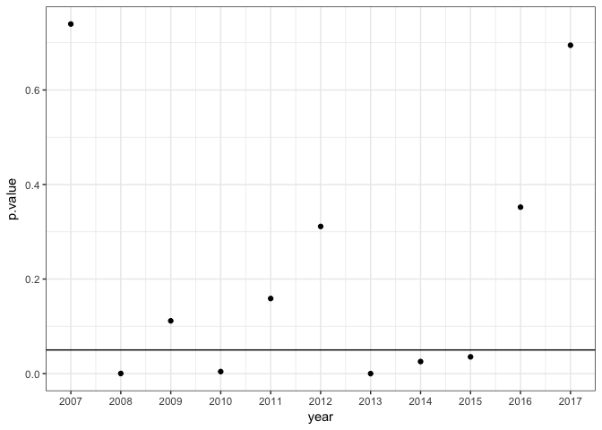

```r
plyr::ldply(unique(df$year), function(x){
  data.frame(p.value = df %>%
               filter(year==x) %>%
               select(support,gov) %>%
               t.test(support~gov,data=.) %>%
               .$p.value,
             year = x)
  }) %>%
  ggplot() +
  geom_point(aes(year,p.value)) +
  geom_hline(yintercept = 0.05) +
  scale_x_continuous(breaks=2007:2017) +
  theme_bw()
```

Paneme lisaks kõrvale keskmised toetusnumbrid antud aastatel.

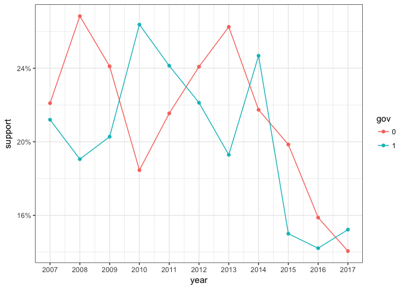

```r
df %>%
  group_by(year,gov=as.factor(gov)) %>%
  summarise(support = mean(support,na.rm=T)) %>%
  ggplot() +
  geom_point(aes(year,support,color=gov)) +
  geom_line(aes(year,support,color=gov)) +
  scale_x_continuous(breaks=2007:2017) +
  scale_y_continuous(labels=scales::percent) +
  theme_bw()
```

### 4.1.3 Kahe sõltuva valimi t-test

Kahe sõltuva valimi t-testi erakonnatoetuse andmestikuga teha ei saa, sest meie uuringu disain ei vasta sellele. Selleks avame ühe teise andmestiku, milleks on paneeluuring enne ja pärast 2014.a. EP valimisi.

```r
summary(paneel)
```

```
       t1.date    t1.evalimiste.usaldus       t2.date
 2014-05-20:115   Min.   : 0.00         2014-06-05:222
 2014-05-12:110   1st Qu.: 5.00         2014-06-03:183
 2014-05-22:109   Median : 8.00         2014-06-09:173
 2014-05-13:106   Mean   :18.41         2014-06-04:154
 2014-05-21:106   3rd Qu.:10.00         2014-06-06:131
 2014-05-19:105   Max.   :98.00         (Other)   :139
 (Other)   :710                         NA's      :359
          t2.osalusviis t2.evalimiste.usaldus
 E-hääletas      :141   Min.   : 0.00
 Ei valinud      :243   1st Qu.: 5.00
 Hääletas paberil:317   Median : 8.00
 NA's            :660   Mean   :16.48
                        3rd Qu.:10.00
                        Max.   :97.00
                        NA's   :359
```

Vaatame näiteks, kas kurikuulus „Haldermanni case“ avaldas mõju e-valimiste usaldusele (vt näit [Eksperdid: Eesti e-valimised on nii ebaturvalised, et tuleks kohe ära lõpetada](http://www.delfi.ee/news/paevauudised/eesti/eksperdid-eesti-e-valimised-on-nii-ebaturvalised-et-tuleks-kohe-ara-lopetada?id=68657131)). Antud asja kajastus levis laiemalt 13. mail selleks ajaks oli paneeluuringu esimeses laines juba piisavalt palju inimesi intervjueeritud, vaatame kas ja kuidas nende usaldus nägi välja enne ja kuidas pärast.

Esimene intervjueerimislaine kestis ka pärast antud juhtumit, mistõttu tuleks sealt välja filtreerida vaatlused pärast 13. maid. Ühtlasi puhastame andmed keeldunud ja puuduvatest väärtustest (kodeeritud 97 ja 98).

```r
enne.parast = paneel %>%
  mutate(t1.date = as.Date(t1.date),
         usaldus.enne = case_when(
           t1.date < as.Date("2014-05-13") & !(t1.evalimiste.usaldus %in% c(97:98)) ~ t1.evalimiste.usaldus),
         usaldus.parast = case_when(
           !(t2.evalimiste.usaldus %in% c(97:98)) ~ t2.evalimiste.usaldus)
         ) %>%
  select(usaldus.enne, usaldus.parast)

summary(enne.parast[c("usaldus.enne", "usaldus.parast")])
```

```
  usaldus.enne    usaldus.parast
 Min.   : 0.000   Min.   : 0.000
 1st Qu.: 5.000   1st Qu.: 5.000
 Median : 8.000   Median : 8.000
 Mean   : 6.767   Mean   : 6.651
 3rd Qu.:10.000   3rd Qu.: 9.000
 Max.   :10.000   Max.   :10.000
 NA's   :1022     NA's   :468
```

Kuidas muuta andmeid R-is *juhul kui* tingimusel. Kõige lihtsam variant on kasutada `ifelse(...)` käsklust, millesse läheb kolm argumenti:

1. tingimus (loogiline võrdlus);
2. väärtus tõese tulemuse korral;
3. väärtus väära tulemuse korral.

Näiteks võtame vektori, mis sisaldab erinevaid taimi ja kodeerime selle ümber puu- ja köögiviljadeks:

```r
taimed = c("apelsin", "kurk", "õun", "porgand", "peet")
ifelse(taimed %in% c("apelsin", "õun"), "puuvili", "köögivili")
```

```
[1] "puuvili"   "köögivili" "puuvili"   "köögivili" "köögivili"
```

Mida aga teha juhul, kui gruppe on üle kahe? *If else* puhul tuleks lisada iga järgnev kriteerium väära väärtussesse:

```r
taimed = c("sibul", "till", "küüslauk", "kapsas", "piparmünt")
ifelse(taimed %in% c("sibul", "küüslauk"), "sibulköögivili",
       ifelse(taimed %in% c("till", "piparmünt"), "maitseköögivili", "lehtköögivili"))
```

```
[1] "sibulköögivili"  "maitseköögivili" "sibulköögivili"  "lehtköögivili"
[5] "maitseköögivili"
```

Gruppide kasvades pole *if else* enam seega sobilik vahend. Paindlikum on kasutada paketist **dplyr** tulenevat funktsiooni `case_when()`, millesse tuleb sisestada vaid kaks argumenti:

1. tingimus;
2. väärtus tõese tulemuse korral.

Argumendid tuleb eraldada sümboliga `~` ja erinevad argumendi read komadega. Väärad tulemused märgitakse vaikimise puuduvateks väärtusteks, kuid ka neile võib anda väärtuse, mispuhul oleks tingimuseks lihtsalt `TRUE`:

```r
case_when(taimed %in% c("sibul", "küüslauk") ~ "sibulköögivili",
          taimed %in% c("till", "piparmünt") ~ "maitseköögivili",
          TRUE ~ "lehtköögivili")
```

```
[1] "sibulköögivili"  "maitseköögivili" "sibulköögivili"  "lehtköögivili"
[5] "maitseköögivili"
```

case_when argumendi ridu saab esitada lõpmatu arv. Rohkem infot: case_when.

Nüüd saame teha kahe sõltuva valimi t-testi.

```r
t.test(enne.parast$usaldus.enne, enne.parast$usaldus.parast, paired=T)
```

```
    Paired t-test

data:  enne.parast$usaldus.enne and enne.parast$usaldus.parast
t = 0.62962, df = 250, p-value = 0.5295
alternative hypothesis: true difference in means is not equal to 0
95 percent confidence interval:
 -0.1865259  0.3618247
sample estimates:
mean of the differences
              0.0876494
```

## 4.2 Anova

Eelmisest ülesandest oli näha, et statistiliselt olulist seost polnud. Kuid et tulemuses päris kindel olla, tuleks võtta arvesse veel teisigi võimalusi:

1. efekt võis olla lühiajaline, mis tähendab, et selle mõju lahtus järeluuringu ajaks;
2. efekt võis sõltuda lisatingimustest, mida eelmises näites arvesse ei võetud.

Kontrollime neid variante! Esmalt vaatame järgi, kas efekt oli lühiajaline. Üks viis selleks on kollabeerida andmed intervjueerimise päevade kaupa ja võrrelda muutust ajas.

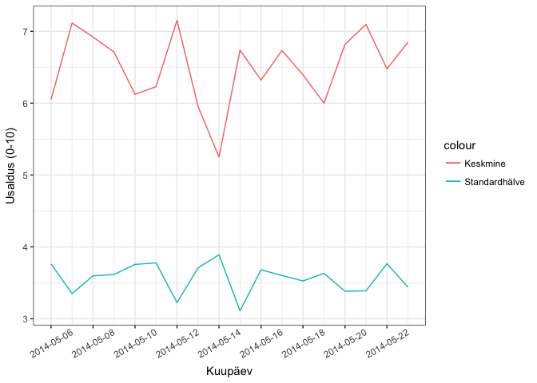

```r
paneel %>%
  mutate(usaldus = case_when(!(t1.evalimiste.usaldus %in% 97:98) ~ t1.evalimiste.usaldus)) %>%
  group_by(t1.date) %>%
  summarise(keskmine = mean(usaldus, na.rm=T),
            sd = sd(usaldus, na.rm=T)) %>%
  ggplot() +
  geom_line(aes(as.Date(t1.date), keskmine, color="Keskmine")) +
  geom_line(aes(as.Date(t1.date), sd, color="Standardhälve")) +
  scale_x_date(date_breaks="2 days") +
  labs(x="Kuupäev", y="Usaldus (0-10)") +
  theme_bw() +
  theme(axis.text.x = element_text(angle=30,vjust=0.6))
```

Tõepoolest on näha, et usaldus langeb 13. ja 14. mai, kuid seejärel taastub.

Teiseks uurime, kas erinevus võib ilmneda mingite kolmandate tunnuste alusel. Andmestikus on meil selleks tunnus osalusviisi kohta.

```r
summary(paneel$t2.osalusviis)
```

```
      E-hääletas       Ei valinud Hääletas paberil             NA's
             141              243              317              660
```

Seega tuleks teha juba varasem enne-pärast võrdlus antud gruppide lõikes. Selleks kasutame ANOVA-t, R-is `aov(...)`:

```r
anova.data = paneel %>%
  mutate(t1.date = as.Date(t1.date),
         usaldus.enne = case_when(
           t1.date < as.Date("2014-05-13") & !(t1.evalimiste.usaldus %in% c(97:98)) ~ t1.evalimiste.usaldus),
         usaldus.parast = case_when(
           !(t2.evalimiste.usaldus %in% c(97:98)) ~ t2.evalimiste.usaldus)
         ) %>%
  select(usaldus.enne, usaldus.parast, t2.osalusviis)

aov(usaldus.enne-usaldus.parast ~ t2.osalusviis, data=anova.data) %>% summary()
```

```
               Df Sum Sq Mean Sq F value Pr(>F)
t2.osalusviis   2   35.2  17.624   3.743 0.0257 *
Residuals     170  800.4   4.708
---
Signif. codes:  0 '***' 0.001 '**' 0.01 '*' 0.05 '.' 0.1 ' ' 1
1188 observations deleted due to missingness
```

Ka siin selgub, et esineb statistiliselt oluline seos. Paraku ei anna anova otsest aimdust selle kohta, milliste gruppide vahel seos on. Hea on seega vaadata jaotusi graafiliselt, näiteks karpdiagrammi abil.

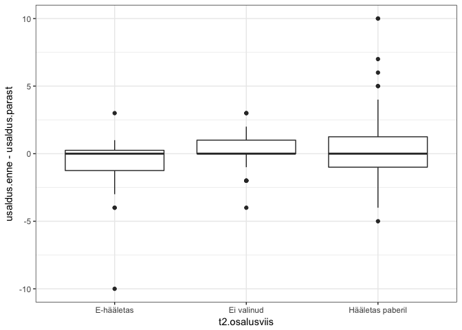

```r
anova.data %>%
  na.omit() %>%
  ggplot() +
  geom_boxplot(aes(t2.osalusviis, usaldus.enne-usaldus.parast)) +
  theme_bw()
```

## 4.3 Efekti suurus (Coheni d)

Tihti huvitab meid statistikas *efekti suurus*. St, kui suurt mõju üks tunnus teisele avaldab. Keskmiste võrdluse puhul loetakse efekti suuruseks erinevust erinevust kahe keskmise vahel, jagatuna andmete standardhälvega:

$d=\frac{\bar{x_1}-\bar{x_2}}{s}$

Antud efekti suurust nimetatakse **Coheni d-ks**. Coheni d leidmiseks kasutame paketti **effsize** ja funktsiooni `cohen.d(...)`, mis jäljendab oma loogikalt t-testi `t.test(...)`. (Antud funktsioon kasutab siiski eelnevalt toodud valemi robustsemat edasiarendust, kuid selle loogika on siiski sama!)

```r
df %>%
  filter(party %in% c("kesk", "ref")) %>%
  cohen.d(support ~ party, data=.)
```

```
Cohen's d

d estimate: 0.536684 (medium)
95 percent confidence interval:
inf sup
NaN NaN
```

# 5 Visualiseerimine

### 5.0.1 Paketid

```r
library(tidyverse)
```

### 5.0.2 Andmestik

```r
df = read.csv("https://martenveskimae.github.io/stat-mod/party_dataset.csv")
paneel = read.csv("https://martenveskimae.github.io/stat-mod/ep2014_paneel.csv")
```

## 5.1 Tulpdiagramm

Tulpdiagramm on sobilik juhul, kui soovime võrrelda kategoorilise tunnuse gruppe ühe või väikese arvu tunnuste lõikes. Juhul, kui tunnuseid on mitu, võib tunnuste väärtused asetada üksteise otsa või üksteise kõrvale (lähemalt all). Antud diagrammi eelis seisneb võimaluses hinnata lihtsa vaevaga tulpade erinevusi tulpade kõrgustes (sellest tulenevalt tuleks võrreldavate tunnuste arv hoida pigem madalal).

Püüame näiteks graafida erakondade keskmised toetusnumbrid aastate lõikes. Tulpdiagrammi loomiseks on funktsioon `geom_col(...)`. Teeme tulpdiagrammi, kus x-teljel on aastad, y-teljel iga erakondade keskmine toetus ning tulba värv on seotud erakonnaga.

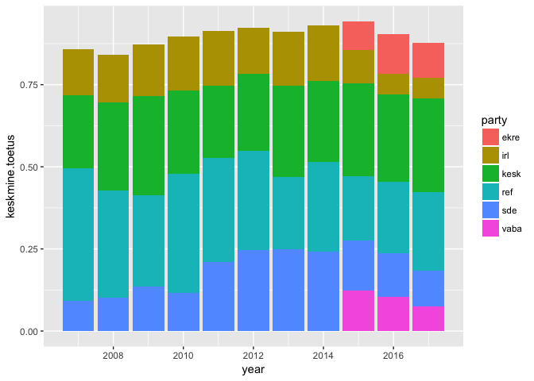

```r
df %>%
  group_by(party, year) %>%
  summarise(keskmine.toetus = mean(support, na.rm=T)) %>%
  ggplot() +
  geom_col(aes(year, keskmine.toetus, fill=party))
```

Antud juhul käsitletakse x-teljel olevat tunnust year arvtunnusena, mistõttu on ggplot ise otsustanud, millise vahega väärtusi joonisel kuvada. Praegu võiks kuvada kõik aastad. Kõige lihtsam variant on kasutada käsklust `as.factor(year)`, mis muudab tunnuse kategooriliseks (võib kasutada nii ggploti sees, kui ka enne seda).

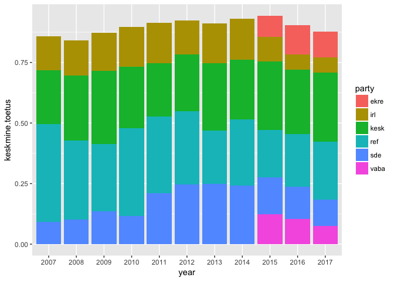

```r
df %>%
  group_by(party, year = as.factor(year)) %>%
  summarise(keskmine.toetus = mean(support, na.rm=T)) %>%
  ggplot() +
  geom_col(aes(year, keskmine.toetus, fill=party))
```

Joonisel on keeruline võrrelda tulpade keskel olevaid erakondi. Parem oleks asetada erinevad erakonnad üksteise kõrvale. Selleks kasutame argumenti **position**: `geom_col(position="dodge")`.

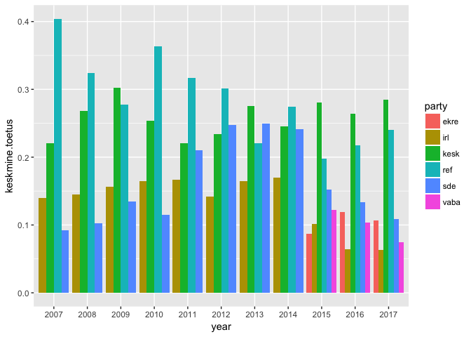

```r
df %>%
  group_by(party, year = as.factor(year)) %>%
  summarise(keskmine.toetus = mean(support, na.rm=T)) %>%
  ggplot() +
  geom_col(aes(year, keskmine.toetus, fill=party), position="dodge")
```

Parem! Järgmiseks oleks hea muuta joonise värve üksteisest selgemalt eristuvaks. Muudame ära ka legendi pealkirja. Selleks peaksime muutma **fill** skaala argumente `scale_fill_brewer(palette="Accent", name="Erakonnad")` (värvide käsitsi sisestamiseks tuleks kasutada `scale_fill_manual(values=c(...))`).

R kasutab värvide genereerimiseks Color Brewerit (pakett RColorBrewer). Rohkem infot: [R Color Cheatsheet](https://www.nceas.ucsb.edu/~frazier/RSpatialGuides/colorPaletteCheatsheet.pdf)

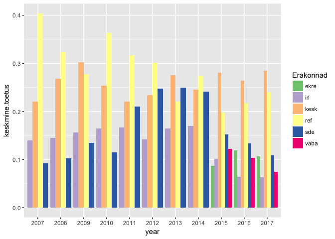

```r
df %>%
  group_by(party, year = as.factor(year)) %>%
  summarise(keskmine.toetus = mean(support, na.rm=T)) %>%
  ggplot() +
  geom_col(aes(year, keskmine.toetus, fill=party), position="dodge") +
  scale_fill_brewer(palette="Accent", name="Erakonnad")
```

Veel tuleks muuta y-telje skaala protsentideks, kasutades selleks paketti *scales* `scale_y_continuous(labels=scales::percent)`. Muudame ära ka telgede nimetused ning lisame pealkirja ja viite käsklusega `labs(x="Aasta", y="Toetus",title="Erakondade keskmine toetus",caption="Kantar Emor küsitlusandmetel")`.

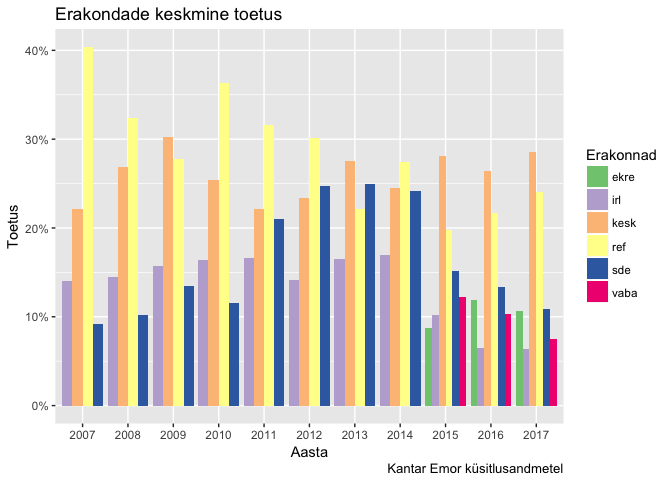

```r
df %>%
  group_by(party, year = as.factor(year)) %>%
  summarise(keskmine.toetus = mean(support, na.rm=T)) %>%
  ggplot() +
  geom_col(aes(year, keskmine.toetus, fill=party), position="dodge") +
  scale_fill_brewer(palette="Accent", name="Erakonnad") +
  scale_y_continuous(labels=scales::percent) +
  labs(x="Aasta", y="Toetus",title="Erakondade keskmine toetus",caption="Kantar Emor küsitlusandmetel")
```

Viimaks muudame joonise tausta valgeks juba tuttava käsklusega `theme_bw()`.

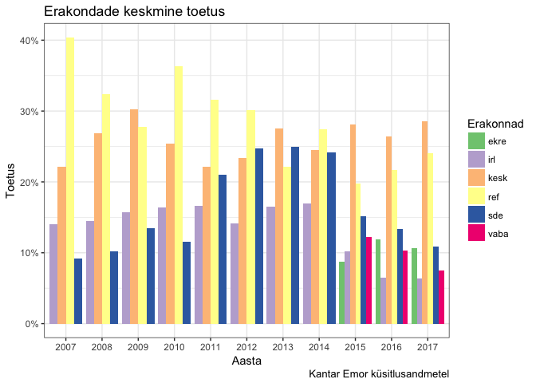

```r
df %>%
  group_by(party, year = as.factor(year)) %>%
  summarise(keskmine.toetus = mean(support, na.rm=T)) %>%
  ggplot() +
  geom_col(aes(year, keskmine.toetus, fill=party), position="dodge") +
  scale_fill_brewer(palette="Accent", name="Erakonnad") +
  scale_y_continuous(labels=scales::percent) +
  labs(x="Aasta", y="Toetus",title="Erakondade keskmine toetus",caption="Kantar Emor küsitlusandmetel") +
  theme_bw()
```